실전에서 바로쓰는 시계열 데이터 처리와 분석의 오탈자 및 수정을 요하는 부분을 정리합니다.

자세한 부분까지 검토해주신 jnhyeon@gmail.com 님께 감사드립니다.

(저보다 자세히 보신 듯하네요..ㅠ.ㅠ)

## P. 13

> POSIXct와 POSIXlt클래스는 1970년 이후의 시간을 초단위로 기록하는 클래스이다.

를

> POSIXct 클래스는 1970년 이후, POSIXlt클래스는 1900년 이후의 시간을 초단위로 기록하는 클래스이다

로 수정합니다.

## P. 24

첫번째 코드설명 중에 두번째 불릿의 두번째 줄

> skip,(skip=16)‘-’

를

> skip(skip=16), ‘-’

로 수정합니다.

## P. 80

코드블럭 중 7번째 줄과 10번째 줄

> geom_line(aes(total, group = 1, color= ‘3개월합계’))

> scale_color_manual(’‘, values = c(’3개월합계’ = ‘red’, ‘3개월 평균’ = ‘blue’))

를

> geom_line(aes(total, group = 1, color= ‘취업자수’))

> scale_color_manual(’‘, values = c(’취업자수’ = ‘red’, ‘3개월 평균’ = ‘blue’))

로 수정합니다.

그러면 플롯은 다음과 같이 수정됩니다.

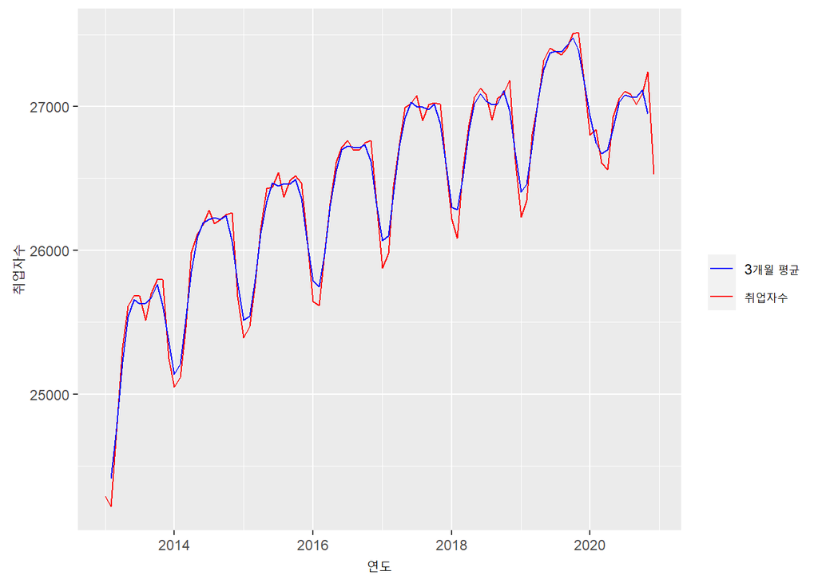

## P.91

xts:diff()의 첫번째 블럭의 두번째 줄

> students.xts$증감율 <- round((students.xts$증감/students.xts$학생수계), 3) * 100

을

> students.xts$증감율 <- round((students.xts$증감/students.xts$유치원), 3) * 100

로 수정합니다.

그러면 결과와 플롯은 다음과 같이 수정됩니다.

```
           유치원  증감 증감율
1999-01-01 534166    NA     NA
2000-01-01 545263 11097    2.0
2001-01-01 545142  -121    0.0
2002-01-01 550256  5114    0.9
2003-01-01 546531 -3725   -0.7
2004-01-01 541713 -4818   -0.9
2005-01-01 541603  -110    0.0
2006-01-01 545812  4209    0.8
2007-01-01 541550 -4262   -0.8
2008-01-01 537822 -3728   -0.7
```

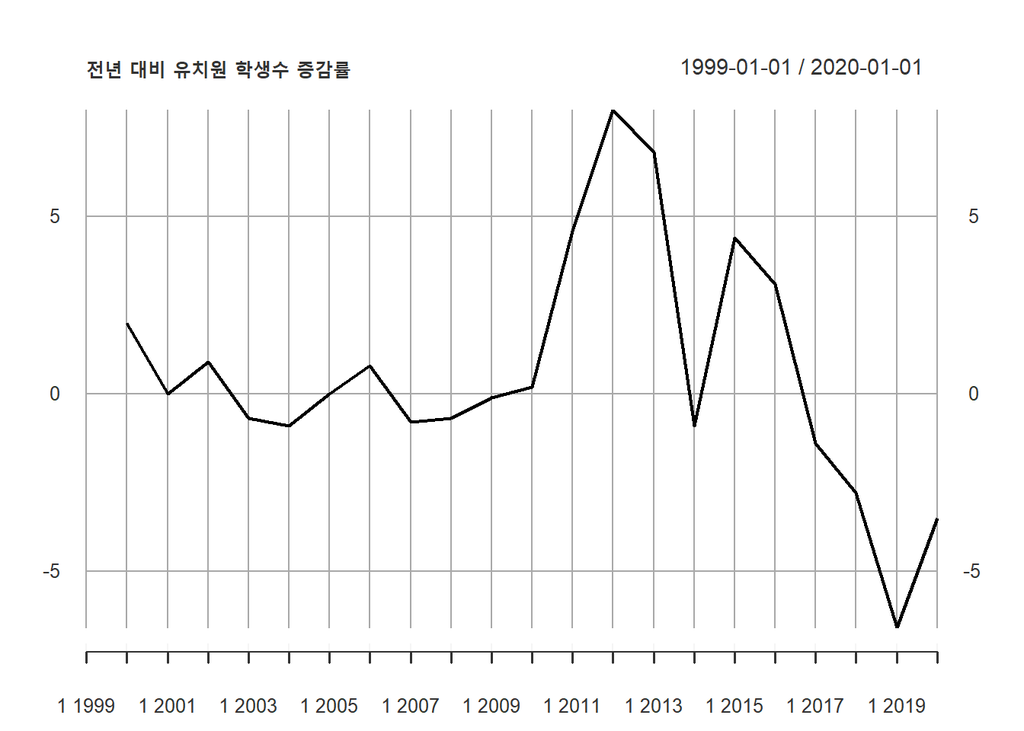

## P.96

첫번째 코드블럭의 첫번째 줄, 두번째 줄, 세번째 줄

> index_by(yearqtr = ~ year(.)) %>%

> mutate(sum.qtrly = sum(total)) %>%

> mutate(rate.qtrly = (total/sum.qtrly)*100) %>%

을

> index_by(yearly = ~ year(.)) %>%

> mutate(sum.yearly = sum(total)) %>%

> mutate(rate.yearly = (total/sum.yearly)*100) %>%

로 수정합니다.

그러면 결과가 다음과 같이 수정됩니다.

```
# A tsibble: 15 x 6 [1D]
# Groups:    @ yearly [2]
   time       total employees.edu yearly sum.yearly rate.yearly
   <date>     <int>         <int>  <dbl>      <int>       <dbl>
 1 2013-01-01 24287          1710   2013     303592        8.00
 2 2013-02-01 24215          1681   2013     303592        7.98
 3 2013-03-01 24736          1716   2013     303592        8.15
 4 2013-04-01 25322          1745   2013     303592        8.34
 5 2013-05-01 25610          1774   2013     303592        8.44
 6 2013-06-01 25686          1786   2013     303592        8.46
 7 2013-07-01 25681          1813   2013     303592        8.46
 8 2013-08-01 25513          1811   2013     303592        8.40
 9 2013-09-01 25701          1794   2013     303592        8.47
10 2013-10-01 25798          1790   2013     303592        8.50
11 2013-11-01 25795          1793   2013     303592        8.50
12 2013-12-01 25248          1779   2013     303592        8.32
13 2014-01-01 25050          1748   2014     310766        8.06
14 2014-02-01 25116          1786   2014     310766        8.08
15 2014-03-01 25463          1814   2014     310766        8.19
```

## P.200

그림 6-56를 다음의 그림으로 수정합니다. (아마도 책에 들어가는 플롯 생성시 `set.seed()`가 문제가 있었던 것으로 보입니다. )

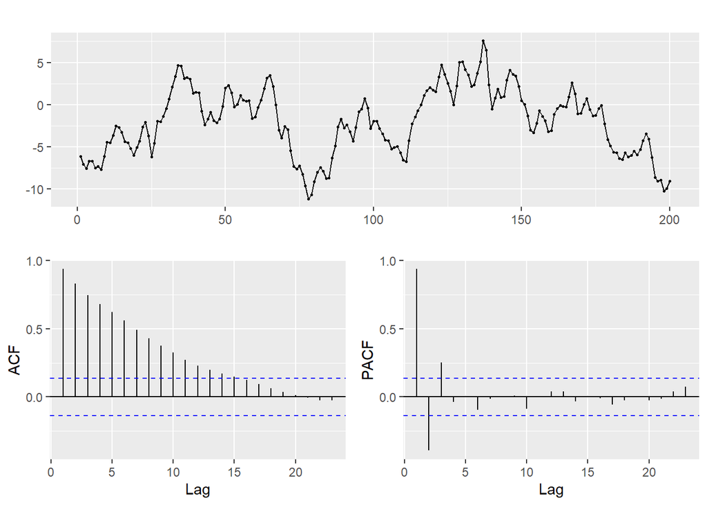

## P.254

코드설명 맨 마지막줄

> ot_modeltime_forecast()를 사용하여 두 모델의 10년치 예측 데이터 플롯을 생성

을

> plot_modeltime_forecast()를 사용하여 두 모델의 10년치 예측 데이터 플롯을 생성

## ggplot의 색깔 문제

ggplot의 색깔이 책과 실제와 다르다는 지적을 주셨는데요.

책의 컬러가 2도이다 보니 컬러와 선 형태를 편집 단계에서 수정할 수 밖에 없었습니다.

이점 양해 부탁드립니다.

## modeltime_refit()

그리고 modeltime 프레임워크를 사용할 때 프레임워크의 워크플로에 따라 최종 선정된 모델에 대한 결과 산출시 `modeltime_refit()`을 사용하는 것이 좋겠다는 의견을 주셨습니다.

modeltime 프레임워크의 워크플로상 지적하신 부분이 일리있다고 생각됩니다. 다만 제 코딩 스타일이 그렇다 보니 전체적인 흐름이 그렇게 되었는데요..

잘못된 부분이라기 보다는 비효율적 코딩 방식이라고 생각됩니다.

다음번 개정판이 나오게 되면 반영하도록 하겠습니다.

**다시한번 의견 주셔서 감사드립니다.**